# Univariate Descriptive Analysis of Preprocessed Data - Flight Prices

## General Statistical Overview

**Information of all variables**

|  | Variable | Type | NAs |
| --- | --- | --- | --- |
| flightDate | flightDate | Date | 0 |
| startApt | startApt | factor | 0 |
| destApt | destApt | factor | 0 |
| elapsedDays | elapsedDays | numeric | 0 |
| economy | economy | factor | 0 |
| nonStop | nonStop | factor | 0 |
| taxAmount | taxAmount | numeric | 0 |
| totalPrice | totalPrice | numeric | 0 |
| seatsLeft | seatsLeft | numeric | 0 |
| travelDistance | travelDistance | numeric | 0 |
| departure | departure | POSIXct/POSIXt | 0 |
| arrival | arrival | POSIXct/POSIXt | 0 |
| airline | airline | factor | 0 |
| equipment | equipment | factor | 322 |
| segmentDistance | segmentDistance | numeric | 0 |
| layoverNumber | layoverNumber | numeric | 0 |

Comparing this table to the raw dataset, we can see the impact of our preprocessing steps. Initially, variables like `travelDistance` and `segmentDistance` had 404 missing values. After the KNN imputation process, these variables have no NAs. However, equipment still shows 322 missing entries because our imputation method focused on numerical variables, leaving categorical fields as they were.

Statistical Summary of Numeric Variables

|  | Variable | Min | Median | Mean | Max | SD | CV |
| --- | --- | --- | --- | --- | --- | --- | --- |
| elapsedDays | elapsedDays | 0.00 | 0.00 | 0.14 | 1.00 | 0.35 | 2.46 |
| taxAmount | taxAmount | 15.95 | 44.32 | 47.88 | 192.93 | 20.51 | 0.43 |
| totalPrice | totalPrice | 33.97 | 299.60 | 330.73 | 837.19 | 168.77 | 0.51 |
| seatsLeft | seatsLeft | 0.00 | 7.00 | 6.06 | 10.00 | 2.90 | 0.48 |
| travelDistance | travelDistance | 97.00 | 1473.00 | 1631.93 | 4173.00 | 854.94 | 0.52 |
| segmentDistance | segmentDistance | 79.00 | 720.00 | 901.83 | 2722.00 | 638.68 | 0.71 |
| layoverNumber | layoverNumber | 0.00 | 1.00 | 0.82 | 3.00 | 0.60 | 0.72 |

The statistics clearly show the effect of our outlier treatment. For instance, the maximum `totalPrice` dropped from 2570 USD to 837 USD, and the `travelDistance` maximum was also adjusted. This confirms that the IQR filter successfully removed the extreme values that were distorting our data. Additionally, the decrease in the Coefficient of Variation (CV) for `totalPrice` (from 0.58 to 0.51) indicates that our dataset is now more consistent.

## Univariate analysis

### Variable: flightDate

| Min. | 1st Qu. | Median | Mean | 3rd Qu. | Max. |
| --- | --- | --- | --- | --- | --- |
| 2022-04-17 | 2022-07-03 | 2022-08-15 | 2022-08-10 | 2022-09-19 | 2022-11-19 |

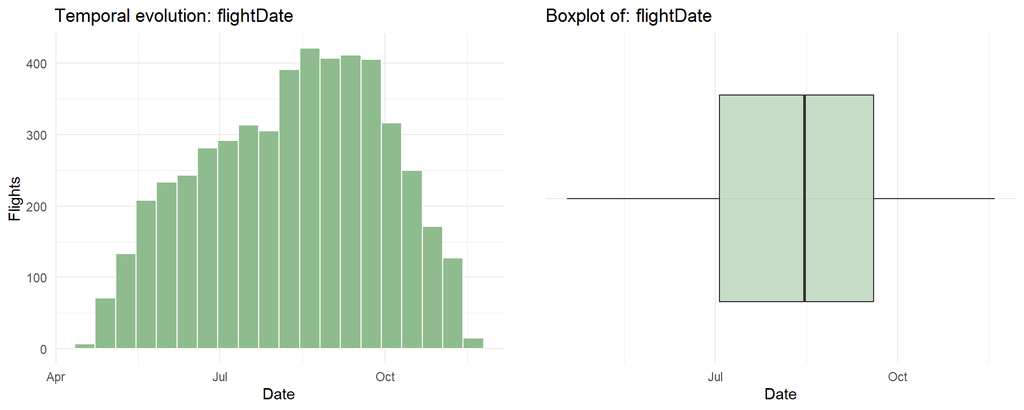

### Variable: startApt

Frequencies of startApt

| Category | Frequency | Percentage |
| --- | --- | --- |
| ATL | 311 | 6.22 |
| BOS | 379 | 7.58 |
| CLT | 350 | 7.00 |
| DEN | 298 | 5.96 |
| DFW | 331 | 6.62 |
| DTW | 302 | 6.04 |
| EWR | 242 | 4.84 |
| IAD | 203 | 4.06 |
| JFK | 302 | 6.04 |
| LAX | 455 | 9.10 |
| LGA | 370 | 7.40 |
| MIA | 320 | 6.40 |
| OAK | 199 | 3.98 |
| ORD | 330 | 6.60 |
| PHL | 299 | 5.98 |
| SFO | 309 | 6.18 |

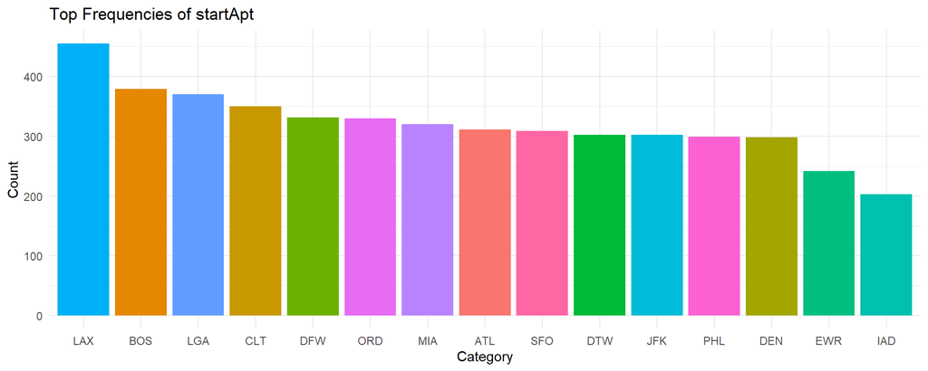

LAX and BOS remain as the main origins.

### Variable: destApt

Frequencies of destApt

| Category | Frequency | Percentage |
| --- | --- | --- |
| ATL | 327 | 6.54 |
| BOS | 341 | 6.82 |
| CLT | 314 | 6.28 |
| DEN | 288 | 5.76 |
| DFW | 350 | 7.00 |
| DTW | 249 | 4.98 |
| EWR | 257 | 5.14 |
| IAD | 226 | 4.52 |
| JFK | 239 | 4.78 |
| LAX | 460 | 9.20 |
| LGA | 373 | 7.46 |
| MIA | 330 | 6.60 |
| OAK | 256 | 5.12 |
| ORD | 370 | 7.40 |
| PHL | 255 | 5.10 |
| SFO | 365 | 7.30 |

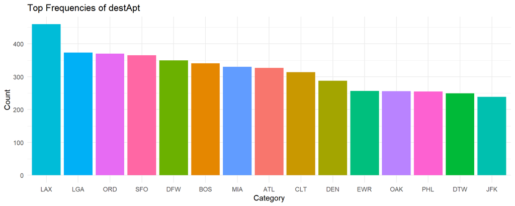

LAX and LGA continue to be the most frequent destinations.

### Variable: elapsedDays

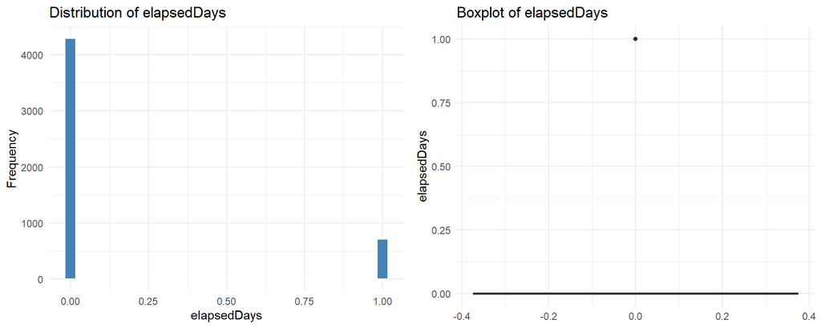

### Variable: economy

Frequencies of economy

| Category | Frequency | Percentage |
| --- | --- | --- |
| FALSE | 4268 | 85.36 |
| TRUE | 732 | 14.64 |

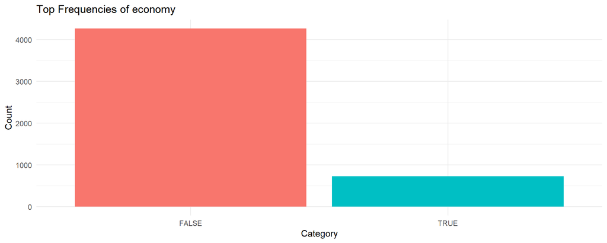

### Variable: nonStop

Frequencies of nonStop

| Category | Frequency | Percentage |
| --- | --- | --- |
| FALSE | 3608 | 72.16 |
| TRUE | 1392 | 27.84 |

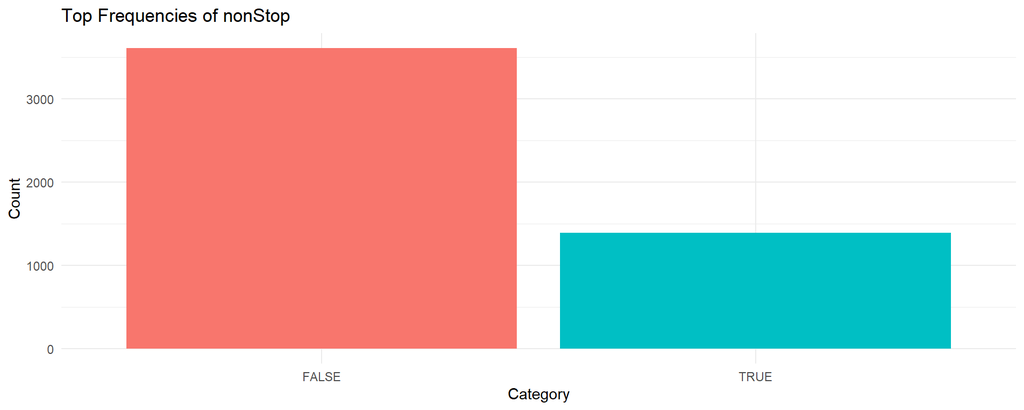

### Variable: taxAmount

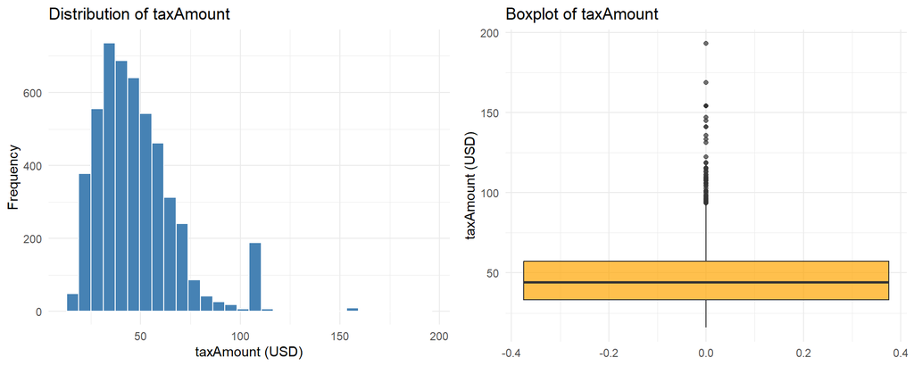

### Variable: totalPrice

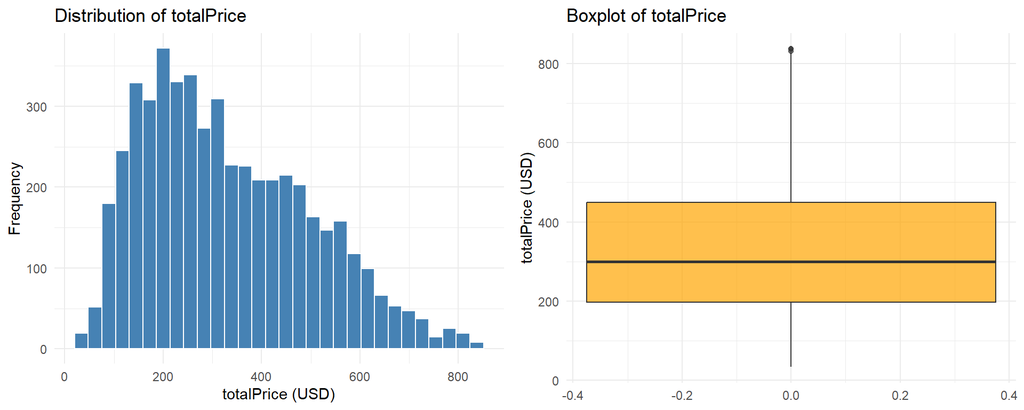

### Variable: seatsLeft

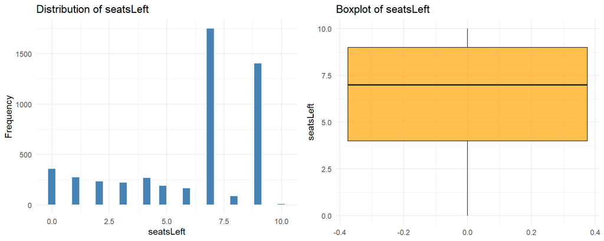

### Variable: travelDistance

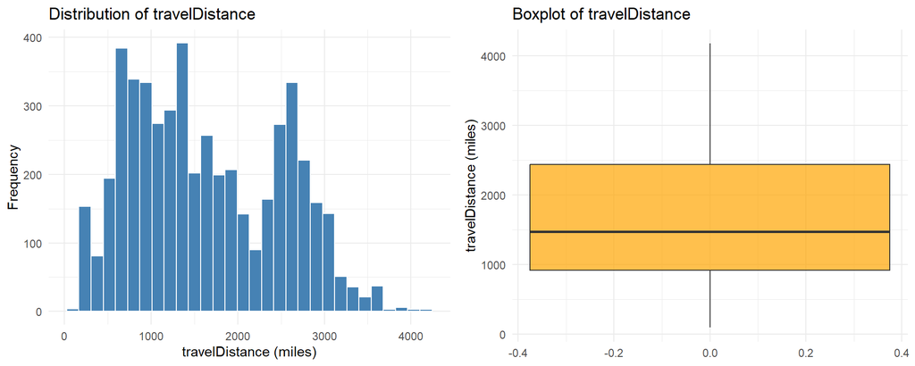

The chart shows two clear groups: short and long flights. Since we filled in the missing data during preprocessing (imputation process), this variable is now complete and reliable for our analysis.

### Variable: departure

| Min. | 1st Qu. | Median | Mean | 3rd Qu. | Max. |
| --- | --- | --- | --- | --- | --- |
| 2022-04-17 17:27:00 | 2022-07-03 10:59:45 | 2022-08-15 18:03:00 | 2022-08-11 01:19:12.144 | 2022-09-19 11:27:30 | 2022-11-19 19:38:00 |

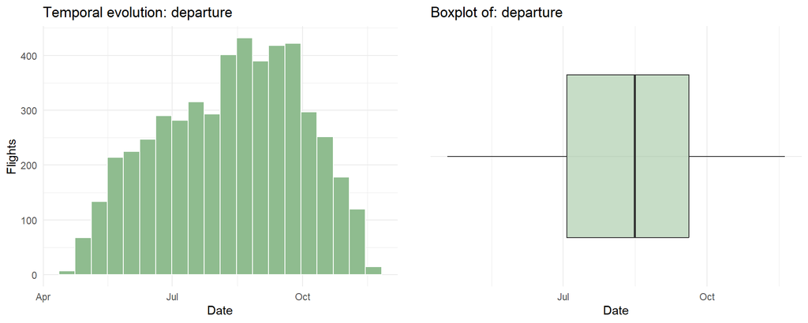

### Variable: arrival

| Min. | 1st Qu. | Median | Mean | 3rd Qu. | Max. |
| --- | --- | --- | --- | --- | --- |
| 2022-04-17 19:38:00 | 2022-07-03 13:53:30 | 2022-08-15 20:42:00 | 2022-08-11 03:57:49.62 | 2022-09-19 13:28:00 | 2022-11-19 22:08:00 |

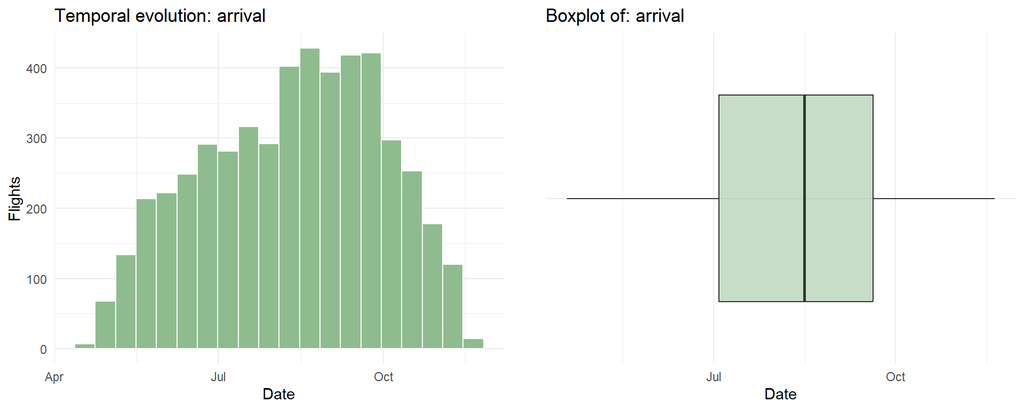

### Variable: airline

Frequencies of airline

| Category | Frequency | Percentage |
| --- | --- | --- |
| Alaska Airlines | 219 | 4.38 |
| American Airlines | 1502 | 30.04 |
| Boutique Air | 2 | 0.04 |
| Cape Air | 2 | 0.04 |
| Delta | 1260 | 25.20 |
| Frontier Airlines | 60 | 1.20 |
| JetBlue Airways | 404 | 8.08 |
| Key Lime Air | 3 | 0.06 |
| Southern Airways Express | 2 | 0.04 |
| Spirit Airlines | 342 | 6.84 |
| Sun Country Airlines | 20 | 0.40 |
| United | 1184 | 23.68 |

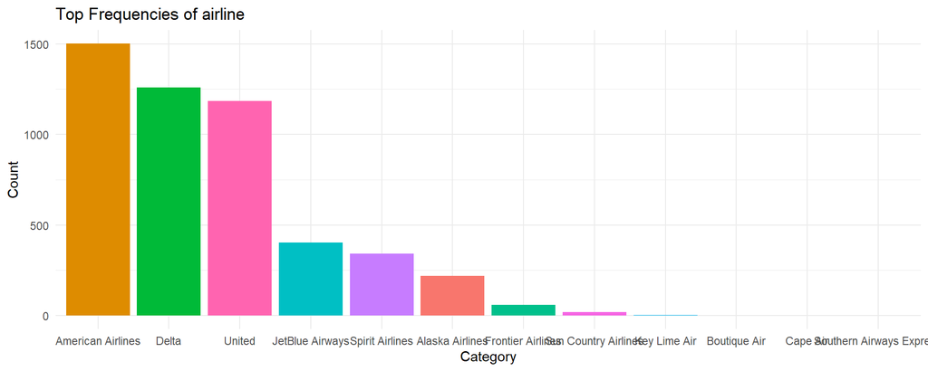

### Variable: equipment

Frequencies of equipment

| Category | Frequency | Percentage |
| --- | --- | --- |
| Airbus A220-100 | 75 | 1.50 |
| Airbus A319 | 413 | 8.26 |
| Airbus A319-321 | 54 | 1.08 |
| Airbus A320 | 419 | 8.38 |
| Airbus A321 | 687 | 13.74 |
| Airbus A330-200 | 1 | 0.02 |
| AIRBUS INDUSTRIE A320 SHARKLETS | 82 | 1.64 |
| AIRBUS INDUSTRIE A321 SHARKLETS | 142 | 2.84 |
| AIRBUS INDUSTRIE A350-900 | 4 | 0.08 |
| Boeing 717 | 167 | 3.34 |
| Boeing 737 | 12 | 0.24 |
| Boeing 737-700 | 50 | 1.00 |
| Boeing 737-800 | 814 | 16.28 |
| Boeing 737-900 | 422 | 8.44 |
| Boeing 737 MAX 8 | 78 | 1.56 |
| Boeing 737 MAX 9 | 94 | 1.88 |
| Boeing 757 | 51 | 1.02 |
| Boeing 757-200 | 63 | 1.26 |
| Boeing 757-300 | 47 | 0.94 |
| Boeing 767 | 3 | 0.06 |
| Boeing 767-300 | 1 | 0.02 |
| Boeing 777 | 49 | 0.98 |
| Boeing 777-200 | 3 | 0.06 |
| BOEING 777-300ER | 8 | 0.16 |
| Boeing 787-8 | 5 | 0.10 |
| BOEING 787-9 | 9 | 0.18 |
| Canadair Regional Jet | 10 | 0.20 |
| Canadair Regional Jet 900 | 169 | 3.38 |
| Canadian Regional Jet 700 | 27 | 0.54 |
| Cessna | 4 | 0.08 |
| Embraer 170 | 45 | 0.90 |
| Embraer 175 | 262 | 5.24 |
| Embraer 175 (Enhanced Winglets) | 257 | 5.14 |
| Embraer 190 | 127 | 2.54 |
| Embraer EMB-145 | 10 | 0.20 |
| Embraer RJ145 | 11 | 0.22 |
| Fairchild Dornier 328 | 1 | 0.02 |
| Pilatus PC-12 | 2 | 0.04 |
| NAs | 322 | 6.44 |

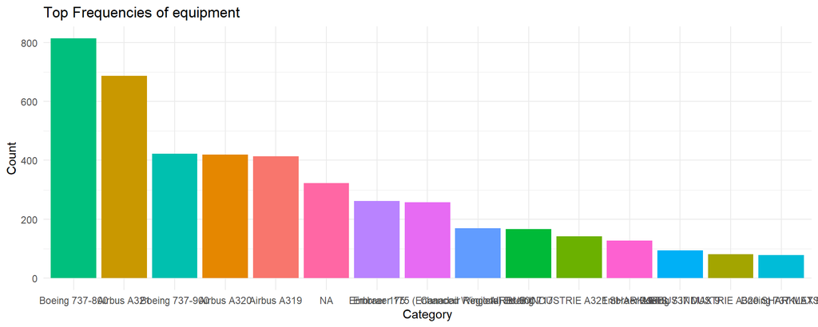

### Variable: segmentDistance

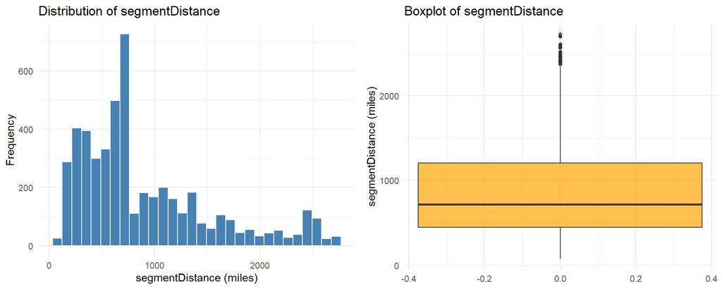

### Variable: layoverNumber

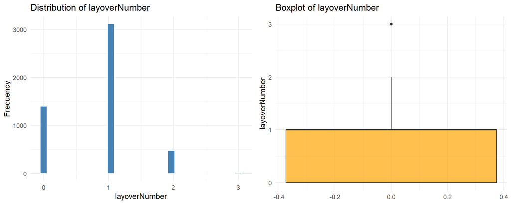